# Data Visualization and Descriptive Statistics in R

# 18 Relationships Between Numerical Variables

## 18.1 Scatterplot

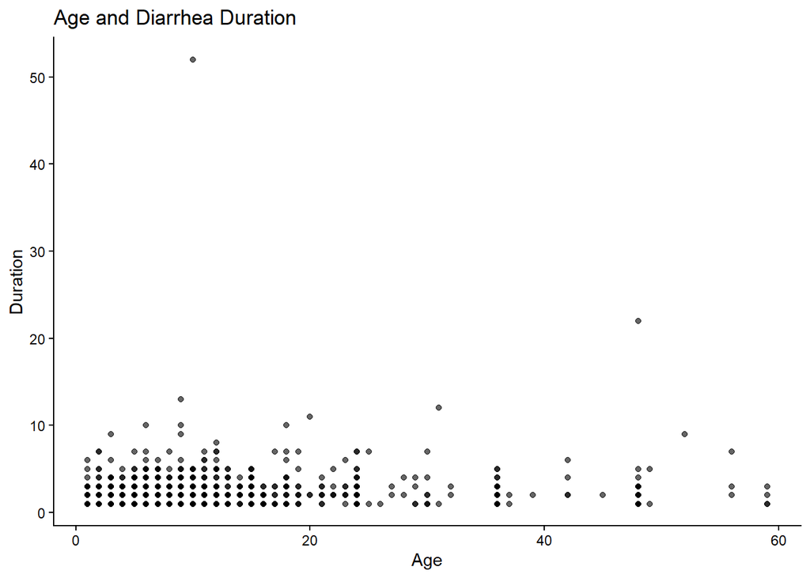

```r
ggplot(
  dirdata,
  aes(x = Age, y = DiaDurInDays)
) +
  geom_point(alpha = 0.6) +
  labs(
    title = "Age and Diarrhea Duration",
    x = "Age",
    y = "Duration"
  )
```

## 18.2 Add a fitted linear trend

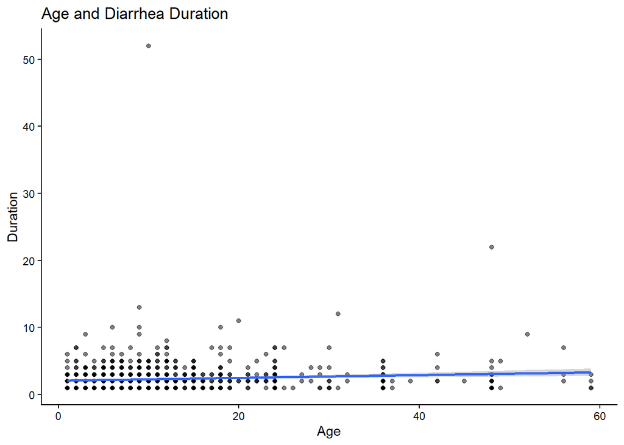

```r
ggplot(
  dirdata,
  aes(x = Age, y = DiaDurInDays)
) +
  geom_point(alpha = 0.5) +
  geom_smooth(
    method = "lm",
    se = TRUE
  ) +
  labs(
    title = "Age and Diarrhea Duration",
    x = "Age",
    y = "Duration"
  )
```

> The regression line is a summary of the observed association. It does not establish causation.

## 18.3 Another relationship

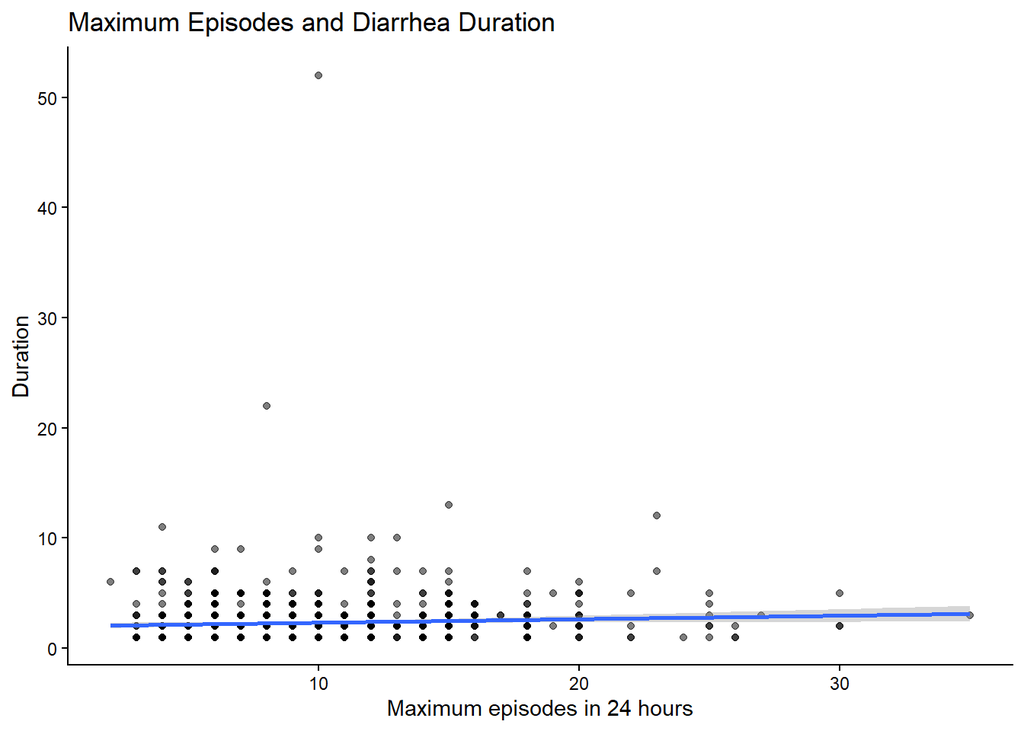

```r
ggplot(
  dirdata,
  aes(x = DiaMaxNo_24hrs, y = DiaDurInDays)
) +
  geom_point(alpha = 0.5) +
  geom_smooth(method = "lm", se = TRUE) +
  labs(
    title = "Maximum Episodes and Diarrhea Duration",
    x = "Maximum episodes in 24 hours",
    y = "Duration"
  )
```

# 19 Correlation

## 19.1 Pearson correlation

```r
cor(
  dirdata$Age,
  dirdata$DiaDurInDays,
  use = "complete.obs"
)
```

```
## [1] 0.1011935
```

## 19.2 Correlation test

```r
cor.test(
  dirdata$Age,
  dirdata$DiaDurInDays,
  use = "complete.obs",
  method = "pearson"
)
```

```
##
##  Pearson's product-moment correlation
##
## data:  dirdata$Age and dirdata$DiaDurInDays
## t = 3.6561, df = 1292, p-value = 0.0002664
## alternative hypothesis: true correlation is not equal to 0
## 95 percent confidence interval:
##  0.04695768 0.15483435
## sample estimates:
##       cor
## 0.1011935
```

## 19.3 Spearman correlation

For ordinal, non-normal, or strongly skewed variables, Spearman correlation may be useful:

```r
cor.test(
  dirdata$Age,
  dirdata$DiaDurInDays,
  use = "complete.obs",
  method = "spearman"
)
```

```
##
##  Spearman's rank correlation rho
##
## data:  dirdata$Age and dirdata$DiaDurInDays
## S = 313095263, p-value = 1.582e-06
## alternative hypothesis: true rho is not equal to 0
## sample estimates:
##       rho
## 0.1329879
```

> Correlation measures association, not causation. Also inspect a scatterplot before relying on a single correlation coefficient.

# 20 Correlation Matrix

```r
numeric_data <- dirdata %>%
  select(
    Age,
    DiaMaxNo_24hrs,
    DiaDurInDays
  )

cor(
  numeric_data,
  use = "pairwise.complete.obs"
)
```

```
##                        Age DiaMaxNo_24hrs DiaDurInDays
## Age             1.00000000    -0.04324656   0.10119346
## DiaMaxNo_24hrs -0.04324656     1.00000000   0.06194965
## DiaDurInDays    0.10119346     0.06194965   1.00000000
```

A simple visual representation:

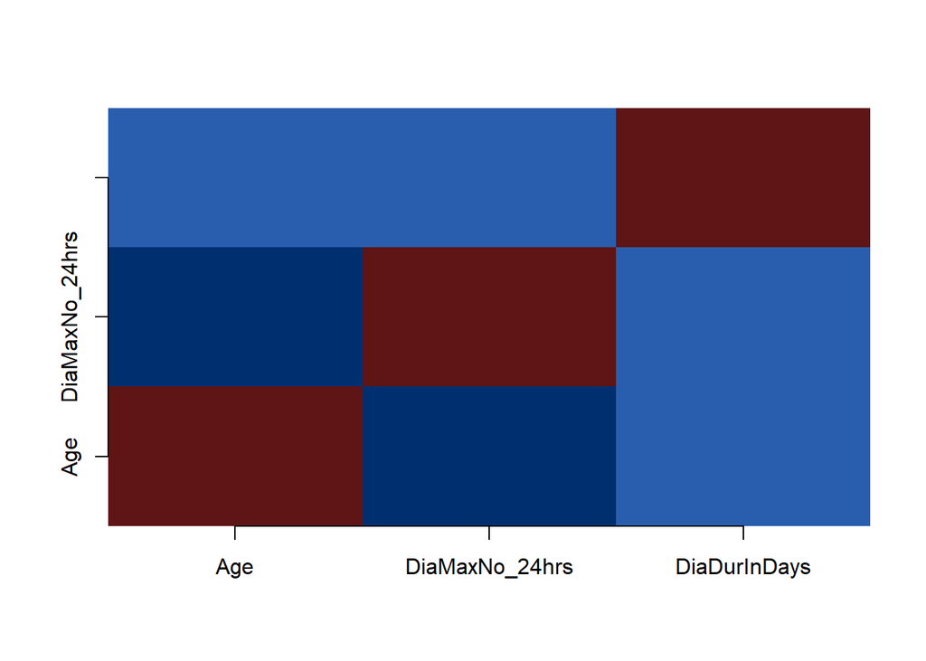

```r
cor_matrix <- cor(
  numeric_data,
  use = "pairwise.complete.obs"
)

image(
  1:ncol(cor_matrix),
  1:nrow(cor_matrix),
  cor_matrix,
  axes = FALSE,
  xlab = "",
  ylab = "",
  col = hcl.colors(20, "Blue-Red 3")
)

axis(
  1,
  at = 1:ncol(cor_matrix),
  labels = colnames(cor_matrix)
)

axis(
  2,
  at = 1:nrow(cor_matrix),
  labels = rownames(cor_matrix)
)
```

# 21 Faceting

Faceting is useful when the same graph should be repeated across groups.

## 21.1 Age distributions by Department

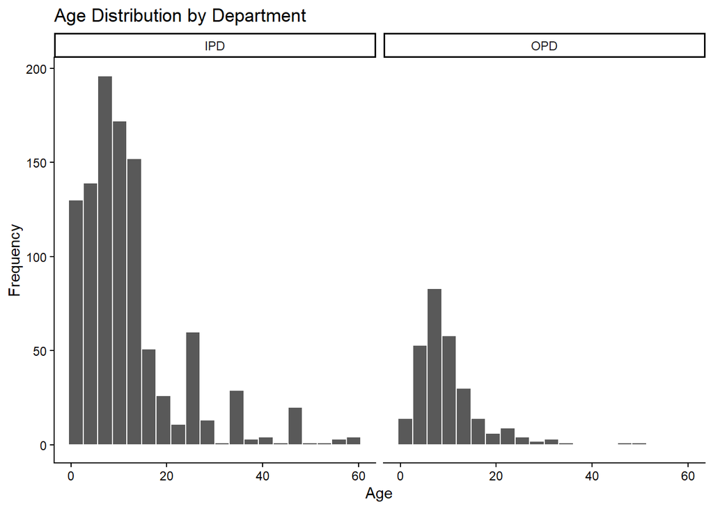

```r
ggplot(dirdata, aes(x = Age)) +
  geom_histogram(bins = 20, color = "white") +
  facet_wrap(~ Department) +
  labs(
    title = "Age Distribution by Department",
    x = "Age",
    y = "Frequency"
  )
```

## 21.2 Age distribution by Sex and Department

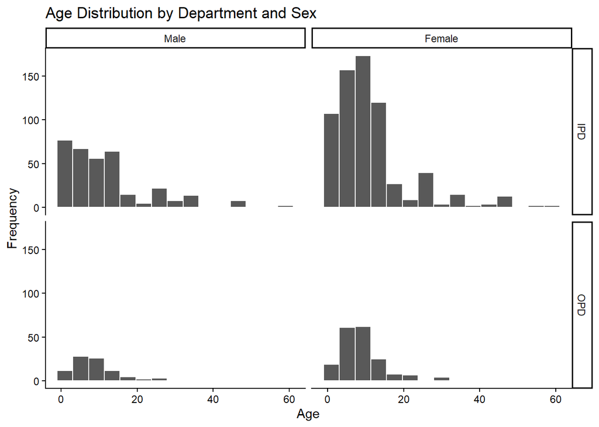

```r
ggplot(dirdata, aes(x = Age)) +
  geom_histogram(bins = 15, color = "white") +
  facet_grid(Department ~ Sex) +
  labs(
    title = "Age Distribution by Department and Sex",
    x = "Age",
    y = "Frequency"
  )
```

# 22 Research-Oriented Summary Tables

## 22.1 Numerical variables

```r
numeric_summary <- dirdata %>%
  summarise(
    across(
      c(Age, DiaMaxNo_24hrs, DiaDurInDays),
      list(
        N = ~ sum(!is.na(.)),
        Mean = ~ mean(.x, na.rm = TRUE),
        SD = ~ sd(.x, na.rm = TRUE),
        Median = ~ median(.x, na.rm = TRUE),
        IQR = ~ IQR(.x, na.rm = TRUE),
        Min = ~ min(.x, na.rm = TRUE),
        Max = ~ max(.x, na.rm = TRUE)
      )
    )
  )

numeric_summary
```

| Age_N | Age_Mean | Age_SD | Age_Median | Age_IQR | Age_Min | Age_Max | DiaMaxNo_24hrs_N | DiaMaxNo_24hrs_Mean | DiaMaxNo_24hrs_SD | DiaMaxNo_24hrs_Median | DiaMaxNo_24hrs_IQR | DiaMaxNo_24hrs_Min | DiaMaxNo_24hrs_Max | DiaDurInDays_N | DiaDurInDays_Mean | DiaDurInDays_SD | DiaDurInDays_Median | DiaDurInDays_IQR | DiaDurInDays_Min | DiaDurInDays_Max |
| --- | --- | --- | --- | --- | --- | --- | --- | --- | --- | --- | --- | --- | --- | --- | --- | --- | --- | --- | --- | --- |
| 1296 | 11.2037 | 9.85643 | 9 | 7 | 1 | 59 | 1296 | 9.83642 | 3.965227 | 9 | 5 | 2 | 35 | 1294 | 2.316074 | 2.040526 | 2 | 2 | 1 | 52 |

## 22.2 Summary by Department

```r
dirdata %>%
  group_by(Department) %>%
  summarise(
    n = n(),
    Mean_Age = mean(Age, na.rm = TRUE),
    SD_Age = sd(Age, na.rm = TRUE),
    Median_Age = median(Age, na.rm = TRUE),
    IQR_Age = IQR(Age, na.rm = TRUE),
    Mean_Duration = mean(DiaDurInDays, na.rm = TRUE),
    Median_Duration = median(DiaDurInDays, na.rm = TRUE),
    .groups = "drop"
  )
```

| Department | n | Mean_Age | SD_Age | Median_Age | IQR_Age | Mean_Duration | Median_Duration |
| --- | --- | --- | --- | --- | --- | --- | --- |
| IPD | 1017 | 11.652901 | 10.515478 | 9 | 7 | 2.418719 | 2 |
| OPD | 279 | 9.566308 | 6.708344 | 8 | 6 | 1.942652 | 2 |

# 23 Confidence Interval for a Mean

A confidence interval describes uncertainty around an estimated mean.

```r
mean_ci <- function(x, conf = 0.95) {
  x <- x[!is.na(x)]
  n <- length(x)
  m <- mean(x)
  se <- sd(x) / sqrt(n)
  tcrit <- qt((1 + conf) / 2, df = n - 1)

  tibble(
    n = n,
    mean = m,
    lower = m - tcrit * se,
    upper = m + tcrit * se
  )
}

mean_ci(dirdata$Age)
```

| n | mean | lower | upper |
| --- | --- | --- | --- |
| 1296 | 11.2037 | 10.66658 | 11.74082 |

By Department:

```r
ci_department <- dirdata %>%
  group_by(Department) %>%
  summarise(
    mean_ci(Age),
    .groups = "drop"
  )

ci_department
```

| Department | n | mean | lower | upper |
| --- | --- | --- | --- | --- |
| IPD | 1017 | 11.652901 | 11.005856 | 12.29995 |
| OPD | 279 | 9.566308 | 8.775709 | 10.35691 |

Plot:

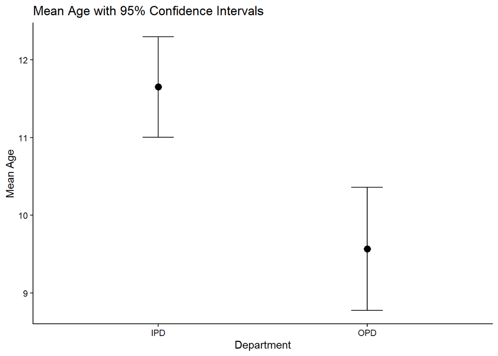

```r
ggplot(
  ci_department,
  aes(x = Department, y = mean)
) +
  geom_point(size = 3) +
  geom_errorbar(
    aes(ymin = lower, ymax = upper),
    width = 0.15
  ) +
  labs(
    title = "Mean Age with 95% Confidence Intervals",
    x = "Department",
    y = "Mean Age"
  )
```

# 24 Optional Inferential Extensions

The main purpose of this module is descriptive analysis. If students continue to inferential statistics, the dataset can be used for introductory examples.

## 24.1 Chi-square test

Example research question:

> Is Department associated with Sex?

```r
tab <- table(dirdata$Department, dirdata$Sex)

chisq.test(tab)
```

```
##
##  Pearson's Chi-squared test with Yates' continuity correction
##
## data:  tab
## X-squared = 0.046246, df = 1, p-value = 0.8297
```

Before interpreting the result, inspect expected counts:

```r
chisq.test(tab)$expected
```

```
##
##       Male Female
##   IPD  339    678
##   OPD   93    186
```

## 24.2 Comparing a numerical variable between two departments

A t-test may be considered when its assumptions are reasonably supported:

```r
t.test(
  Age ~ Department,
  data = dirdata
)
```

```
##
##  Welch Two Sample t-test
##
## data:  Age by Department
## t = 4.0155, df = 692.95, p-value = 6.581e-05
## alternative hypothesis: true difference in means between group IPD and group OPD is not equal to 0
## 95 percent confidence interval:
##  1.066338 3.106847
## sample estimates:
## mean in group IPD mean in group OPD
##         11.652901          9.566308
```

A non-parametric alternative is:

```r
wilcox.test(
  Age ~ Department,
  data = dirdata
)
```

```
##
##  Wilcoxon rank sum test with continuity correction
##
## data:  Age by Department
## W = 151322, p-value = 0.08727
## alternative hypothesis: true location shift is not equal to 0
```

> These tests should not be presented as automatic steps. Students should first examine the study design, measurement scale, distribution, independence, missing data, and assumptions.

# 25 Interpreting Graphs Correctly

A graph should lead to a **description supported by the graph**, not an unsupported conclusion.

## 25.1 Example: histogram

A useful interpretation discusses:

- centre;
- spread;
- shape;
- skewness;
- unusual observations.

Avoid:

> “Age causes longer diarrhea duration.”

A scatterplot cannot support a causal statement.

Prefer:

> “The scatterplot shows the observed association between age and diarrhea duration. The direction and strength should be assessed from the pattern of points and an appropriate correlation or model.”

## 25.2 Example: boxplot

A good interpretation may discuss:

- median;
- interquartile range;
- overall spread;
- potential outliers;
- differences between groups.

# 26 Publication-Quality Graphs

A research graph should have:

- a meaningful title or caption;
- clear axis labels;
- correct units where known;
- readable text;
- an appropriate scale;
- a useful legend;
- minimal unnecessary decoration;
- an appropriate graph type.

Example:

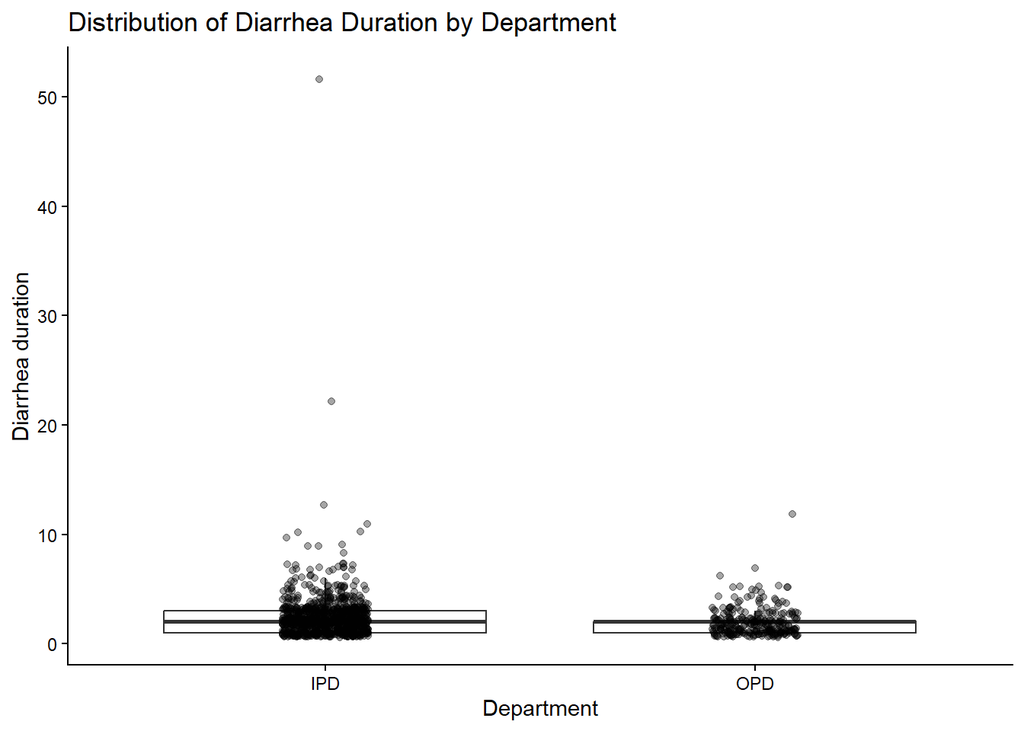

```r
p <- ggplot(
  dirdata,
  aes(x = Department, y = DiaDurInDays)
) +
  geom_boxplot(outlier.shape = NA) +
  geom_jitter(
    width = 0.1,
    alpha = 0.35
  ) +
  labs(
    title = "Distribution of Diarrhea Duration by Department",
    x = "Department",
    y = "Diarrhea duration"
  ) +
  theme_classic()

p
```

# 27 Saving Figures

```r
ggsave(
  "diarrhea_duration_by_department.png",
  plot = p,
  width = 7,
  height = 5,
  units = "in",
  dpi = 300
)
```

For PDF:

```r
ggsave(
  "diarrhea_duration_by_department.pdf",
  plot = p,
  width = 7,
  height = 5
)
```

# 28 Mini Analysis Workflow

The following workflow is recommended for a real analysis.

```r
### Import
data <- read_csv(
  url,
  na = c("", "NA", "N/A", "NULL")
)
### Clean variable types
data <- data %>%
  mutate(
    Department = factor(str_to_upper(str_trim(Department))),
    Sex = factor(Sex, levels = c(1, 2),
                 labels = c("Male", "Female")),
    Fever = factor(str_to_title(str_trim(Fever)),
                   levels = c("No", "Yes")),
    DegreeDehy = factor(
      str_to_lower(str_trim(DegreeDehy)),
      levels = c("some", "severe"),
      labels = c("Some", "Severe")
    ),
    OutComeDisc = factor(str_trim(OutComeDisc))
  )

### Audit
dim(data)
```

```
## [1] 1296    9
```

```r
str(data)
```

```
## tibble [1,296 × 9] (S3: tbl_df/tbl/data.frame)
##  $ ID            : num [1:1296] 1 2 3 4 5 6 7 8 9 10 ...
##  $ Department    : Factor w/ 2 levels "IPD","OPD": 2 2 1 1 1 2 1 1 1 1 ...
##  $ Sex           : Factor w/ 2 levels "Male","Female": 1 2 1 1 1 2 2 1 2 1 ...
##  $ Age           : num [1:1296] 6 8 12 2 12 12 10 21 6 37 ...
##  $ Fever         : Factor w/ 2 levels "No","Yes": 1 1 1 2 2 1 1 1 1 1 ...
##  $ DiaMaxNo_24hrs: num [1:1296] 7 5 10 9 8 7 12 8 8 10 ...
##  $ DiaDurInDays  : num [1:1296] 2 1 3 1 2 5 2 2 2 2 ...
##  $ DegreeDehy    : Factor w/ 2 levels "Some","Severe": 1 1 1 1 1 1 1 1 1 1 ...
##  $ OutComeDisc   : Factor w/ 1 level "Improved": NA NA 1 1 1 NA 1 1 1 1 ...
```

```r
colSums(is.na(data))
```

```
##             ID     Department            Sex            Age          Fever
##              0              0              0              0              1
## DiaMaxNo_24hrs   DiaDurInDays     DegreeDehy    OutComeDisc
##              0              2              0            196
```

```r
### Describe numerical variables
data %>%
  summarise(
    across(
      c(Age, DiaMaxNo_24hrs, DiaDurInDays),
      list(
        mean = ~ mean(.x, na.rm = TRUE),
        median = ~ median(.x, na.rm = TRUE),
        sd = ~ sd(.x, na.rm = TRUE),
        IQR = ~ IQR(.x, na.rm = TRUE)
      )
    )
  )
```

| Age_mean | Age_median | Age_sd | Age_IQR | DiaMaxNo_24hrs_mean | DiaMaxNo_24hrs_median | DiaMaxNo_24hrs_sd | DiaMaxNo_24hrs_IQR | DiaDurInDays_mean | DiaDurInDays_median | DiaDurInDays_sd | DiaDurInDays_IQR |
| --- | --- | --- | --- | --- | --- | --- | --- | --- | --- | --- | --- |
| 11.2037 | 9 | 9.85643 | 7 | 9.83642 | 9 | 3.965227 | 5 | 2.316074 | 2 | 2.040526 | 2 |

```r
### Describe categorical variables
data %>%
  count(Department) %>%
  mutate(Percent = 100 * n / sum(n))
```

| Department | n | Percent |
| --- | --- | --- |
| IPD | 1017 | 78.47222 |
| OPD | 279 | 21.52778 |

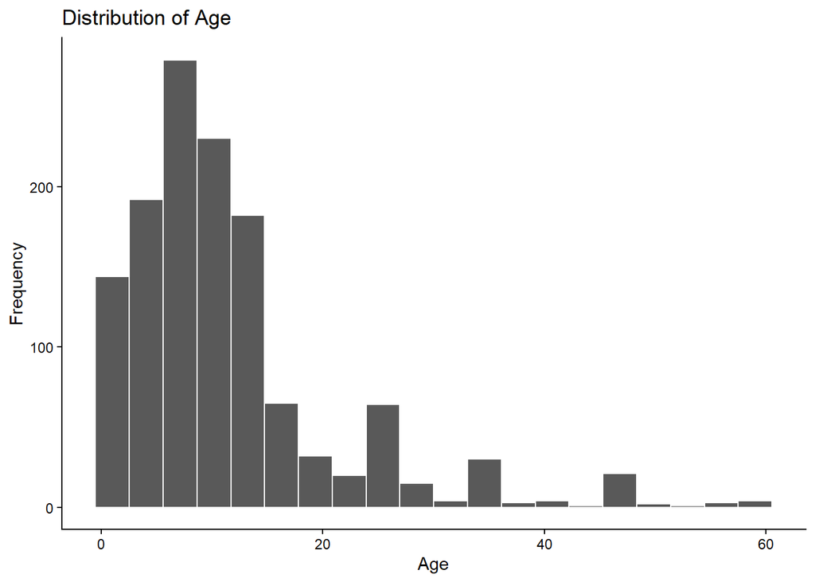

```r
### Visualize
ggplot(data, aes(x = Age)) +
  geom_histogram(bins = 20, color = "white") +
  labs(
    title = "Distribution of Age",
    x = "Age",
    y = "Frequency"
  )
```

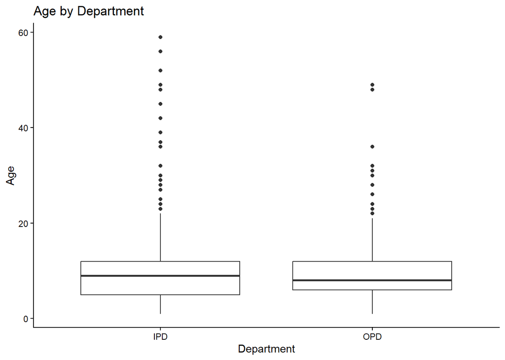

```r
### Compare groups
ggplot(data, aes(x = Department, y = Age)) +
  geom_boxplot() +
  labs(
    title = "Age by Department",
    x = "Department",
    y = "Age"
  )
```

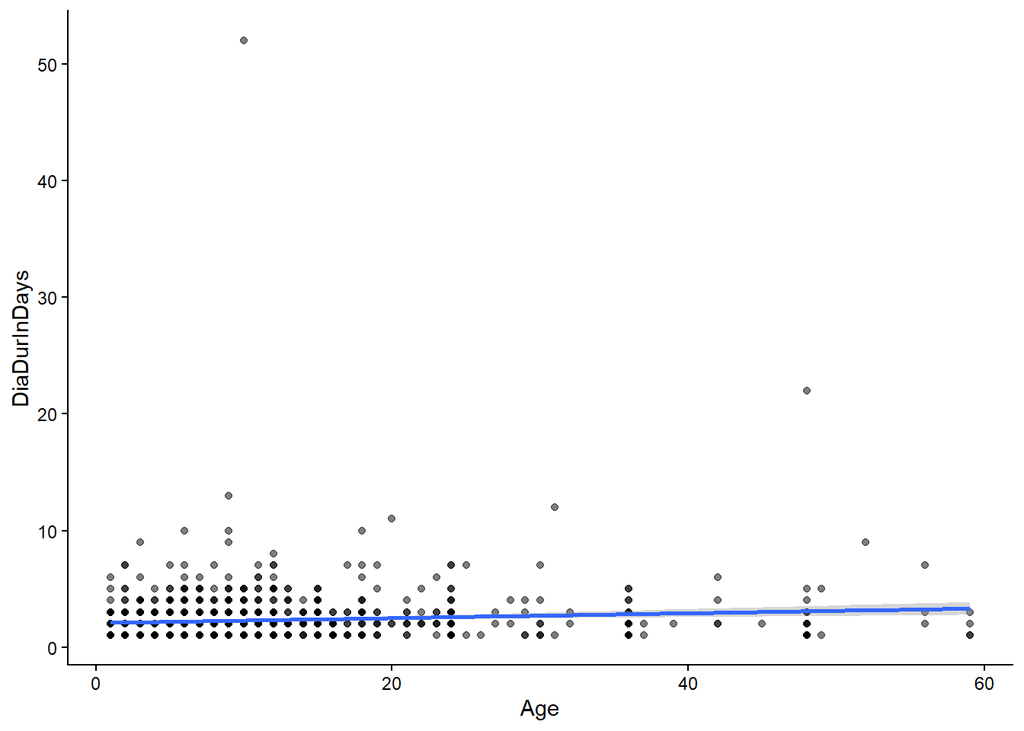

```r
### Examine a relationship
ggplot(data, aes(x = Age, y = DiaDurInDays)) +
  geom_point(alpha = 0.5) +
  geom_smooth(method = "lm", se = TRUE)
```

# 29 Exercises

## 29.1 Exercise 1: Data Audit

Using `dirdata`:

1. How many observations are present?
2. How many variables are present?
3. Which variables are categorical?
4. Which variables are numerical?
5. Which variables contain missing values?
6. Are there duplicated IDs?
7. What unique values occur in `DegreeDehy` before cleaning?
8. What unique values occur after cleaning?

## 29.2 Exercise 2: Descriptive Statistics

Calculate for `Age`, `DiaMaxNo_24hrs`, and `DiaDurInDays`:

1. mean;
2. median;
3. standard deviation;
4. minimum;
5. maximum;
6. quartiles;
7. IQR.

Then explain why the mean and median may differ.

## 29.3 Exercise 3: Categorical Variables

Calculate frequency and percentage tables for:

1. Department;
2. Sex;
3. Fever;
4. Degree of dehydration;
5. Outcome.

Then create a bar chart for each variable.

## 29.4 Exercise 4: Group Comparison

Compare `Age` between Departments using:

1. a boxplot;
2. a boxplot with jittered observations;
3. group-specific descriptive statistics.

Write a short paragraph describing what the graphs show.

## 29.5 Exercise 5: Diarrhea Duration

Study `DiaDurInDays`:

1. create a histogram;
2. create a density plot;
3. create a boxplot;
4. identify potential outliers;
5. investigate unusually large values;
6. calculate mean, median, SD and IQR.

Do not remove observations simply because they are outliers.

## 29.6 Exercise 6: Relationships

Investigate:

1. `Age` versus `DiaDurInDays`;
2. `DiaMaxNo_24hrs` versus `DiaDurInDays`.

For each:

- make a scatterplot;
- add a fitted trend line;
- calculate Pearson correlation;
- calculate Spearman correlation;
- write a short interpretation.

## 29.7 Exercise 7: Two Categorical Variables

Investigate the relationship between:

- Department and Sex;
- Department and Fever;
- Department and DegreeDehy.

For each:

1. create a contingency table;
2. calculate appropriate percentages;
3. create a grouped or proportional bar chart;
4. describe the observed pattern.

## 29.8 Exercise 8: Research-Style Figure

Create one final figure suitable for inclusion in a report or manuscript. It must contain:

- a meaningful title/caption;
- clear axis labels;
- appropriate units where known;
- readable text;
- no unnecessary decoration.

## 29.9 Exercise 9: Short Research Summary

Write 150–250 words describing the dataset using:

- one numerical summary table;
- one categorical summary;
- one distribution graph;
- one group-comparison graph;
- one relationship graph.

Do not make causal claims.

# 30 Suggested Final Student Assignment

Conduct a complete exploratory analysis of the diarrhea dataset.

Your report should contain:

### 30.0.1 Data description

- number of observations;
- number of variables;
- variable types;
- missing-data summary.

### 30.0.2 Descriptive statistics

Report appropriate statistics for numerical variables.

### 30.0.3 Categorical summaries

Report frequencies and percentages.

### 30.0.4 Visualizations

Include at least:

1. one histogram;
2. one boxplot;
3. one categorical bar chart;
4. one group-comparison graph;
5. one scatterplot.

### 30.0.5 Data-quality discussion

Discuss:

- missing values;
- inconsistent labels;
- potential outliers;
- any values requiring verification.

### 30.0.6 Interpretation

Explain what the analysis shows without making unsupported causal claims.

# 31 Common Mistakes to Avoid

## 31.1 Calling every numerical variable continuous

Counts such as `DiaMaxNo_24hrs` are discrete counts.

## 31.2 Assuming units that are not documented

Do not label `Age` as months, years, or another unit unless the original documentation confirms it.

## 31.3 Treating missing values as zero

A missing value is not automatically zero.

## 31.4 Deleting outliers automatically

First investigate whether the value is a valid observation.

## 31.5 Confusing correlation with causation

A correlation does not demonstrate a causal relationship.

## 31.6 Using the wrong graph

- categorical → usually bar chart;
- numerical distribution → histogram/density;
- numerical by group → boxplot/violin;
- two numerical variables → scatterplot.

## 31.7 Overusing pie charts

Bar charts generally make category comparisons easier.

## 31.8 Using too many colors

Use colour when it communicates information, not simply for decoration.

## 31.9 Reporting only p-values

Statistical analysis should also communicate effect size, uncertainty, direction, and practical meaning where appropriate.

# 32 Quick Reference

## 32.1 Descriptive statistics

| Purpose | R function |
| --- | --- |
| Mean | `mean()` |
| Median | `median()` |
| Minimum | `min()` |
| Maximum | `max()` |
| Range | `range()` |
| Variance | `var()` |
| Standard deviation | `sd()` |
| Quartiles | `quantile()` |
| IQR | `IQR()` |
| Five-number summary | `fivenum()` |

## 32.2 Frequency analysis

| Purpose | R function |
| --- | --- |
| Frequency | `table()` / `count()` |
| Proportion | `prop.table()` |
| Cross-tabulation | `table()` |
| Tidy cross-tabulation | `count()` |

## 32.3 ggplot2

| Purpose | Function |
| --- | --- |
| Start graph | `ggplot()` |
| Histogram | `geom_histogram()` |
| Density | `geom_density()` |
| Boxplot | `geom_boxplot()` |
| Violin plot | `geom_violin()` |
| Points | `geom_point()` |
| Jitter | `geom_jitter()` |
| Bar chart | `geom_bar()` |
| Trend line | `geom_smooth()` |
| Labels | `labs()` |
| Faceting | `facet_wrap()` / `facet_grid()` |
| Flip coordinates | `coord_flip()` |
| Save figure | `ggsave()` |

# 33 Graph Selection Guide

```
START
  +-- What type of variable?
        +-- Categorical
        |      |
        |      +-- One variable
        |      |      -> Bar chart
        |      |
        |      +-- Two variables
        |             -> Grouped / proportional bar chart
        +-- Numerical
               +-- One variable
               |      -> Histogram / Density / Boxplot
               +-- Numerical + categorical
               |      -> Boxplot / Violin / Faceted distribution
               +-- Two numerical variables
                      -> Scatterplot
                      -> Add trend line if appropriate
                      -> Consider correlation
```

# 34 Final Checklist

Before presenting an analysis, ask:

- Did I inspect the raw data first?
- Did I verify the number of observations and variables?
- Did I check missing values?
- Did I check inconsistent category labels?
- Did I check duplicate IDs?
- Did I verify variable types?
- Did I avoid assuming undocumented units?
- Did I choose an appropriate statistic?
- Did I choose an appropriate graph?
- Are axes and labels clear?
- Are units reported when known?
- Did I investigate unusual observations?
- Did I avoid automatically deleting outliers?
- Did I distinguish association from causation?
- Can another researcher reproduce my analysis from the code?

# 35 Final Remarks

Good statistical analysis is more than producing numbers and attractive graphs.

A strong exploratory analysis follows a logical sequence:

1. **understand the data;**
2. **audit data quality;**
3. **clean and document variables;**
4. **summarize the data numerically;**
5. **visualize distributions;**
6. **compare relevant groups;**
7. **examine relationships;**
8. **investigate unusual observations;**
9. **interpret results cautiously;**
10. **communicate the evidence clearly.**

The diarrhea dataset provides a useful teaching example because it contains numerical and categorical variables, missing values, inconsistent text labels, group structure, and observations that warrant investigation. These features make it suitable not only for learning `ggplot2` and descriptive statistics, but also for learning an essential research skill: **checking the data before trusting the analysis**.